# Homework 3

Michael Sack

## Classification

For this assignment, we will be working with part of a [Kaggle data set](https://www.kaggle.com/c/titanic/overview) that was the subject of a machine learning competition and is often used for practicing ML models. The goal is classification; specifically, to predict which passengers would survive the [Titanic shipwreck](https://en.wikipedia.org/wiki/Titanic).

Load the data from `data/titanic.csv` into *R* and familiarize yourself with the variables it contains using the codebook (`data/titanic_codebook.txt`).

Notice that `survived` and `pclass` should be changed to factors. When changing `survived` to a factor, you may want to reorder the factor so that *“Yes”* is the first level.

Make sure you load the `tidyverse` and `tidymodels`!

*Remember that you’ll need to set a seed at the beginning of the document to reproduce your results.*

```r
#install.packages("ggplot2")
#install.packages("tidyverse")
#install.packages("tidymodels")
#install.packages('yardstick')
library(ggplot2)
library(tidyverse)
library(tidymodels)
library(yardstick)
library(corrr)
library(pROC)
library(ISLR) # For the Smarket data set
library(ISLR2) # For the Bikeshare data set
library(discrim)
library(poissonreg)
library(klaR) # for naive bayes
tidymodels_prefer()
```

```r
titanic <- read_csv("/Users/michellesack/Desktop/UCSB/Senior yr/Spring/PSTAT 131/homework-3/data/titanic.csv")
```

```r
titanic$survived <- as.factor(titanic$survived)
titanic$pclass <- as.factor(titanic$pclass)
```

### Question 1

Split the data, stratifying on the outcome variable, `survived.` You should choose the proportions to split the data into. Verify that the training and testing data sets have the appropriate number of observations. Take a look at the training data and note any potential issues, such as missing data.

```r
set.seed(2208)
titanic_split <- initial_split(titanic, prop = 0.80,
                                strata = survived)
titanic_train <- training(titanic_split)
titanic_test <- testing(titanic_split)
nrow(titanic_train)
```

```
## [1] 712
```

```r
nrow(titanic_test)
```

```
## [1] 179
```

```r
nrow(titanic)
```

```
## [1] 891
```

```r
titanic_train %>%
  head()
```

```
## # A tibble: 6 × 12
##   passenger_id survived pclass name  sex     age sib_sp parch ticket  fare cabin
##          <dbl> <fct>    <fct>  <chr> <chr> <dbl>  <dbl> <dbl> <chr>  <dbl> <chr>
## 1            1 No       3      Brau… male     22      1     0 A/5 2…  7.25 <NA>
## 2            5 No       3      Alle… male     35      0     0 373450  8.05 <NA>
## 3            6 No       3      Mora… male     NA      0     0 330877  8.46 <NA>
## 4            7 No       1      McCa… male     54      0     0 17463  51.9  E46
## 5           13 No       3      Saun… male     20      0     0 A/5. …  8.05 <NA>
## 6           14 No       3      Ande… male     39      1     5 347082 31.3  <NA>
## # … with 1 more variable: embarked <chr>
```

There appears to be some missing data for the variable “age”.

Why is it a good idea to use stratified sampling for this data?

It is a good idea to use stratified sampling on this data because it will help to assure the subgroups within the data have an even distribution and do not skew our results.

### Question 2

Using the **training** data set, explore/describe the distribution of the outcome variable `survived`.

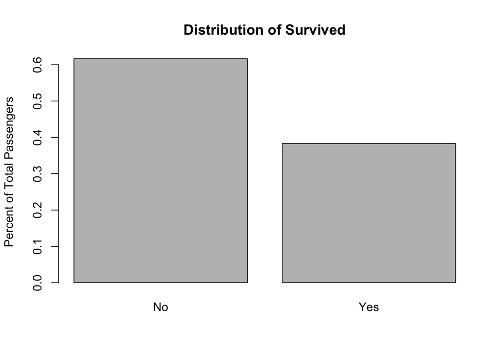

```r
titanic_survived <- titanic_train$survived
barplot(prop.table(table(titanic_survived)),  main= "Distribution of Survived", ylab= "Percent of Total Passengers")
```

It appears that 60% of the passengers did not survive.

### Question 3

Using the **training** data set, create a correlation matrix of all continuous variables. Create a visualization of the matrix, and describe any patterns you see.

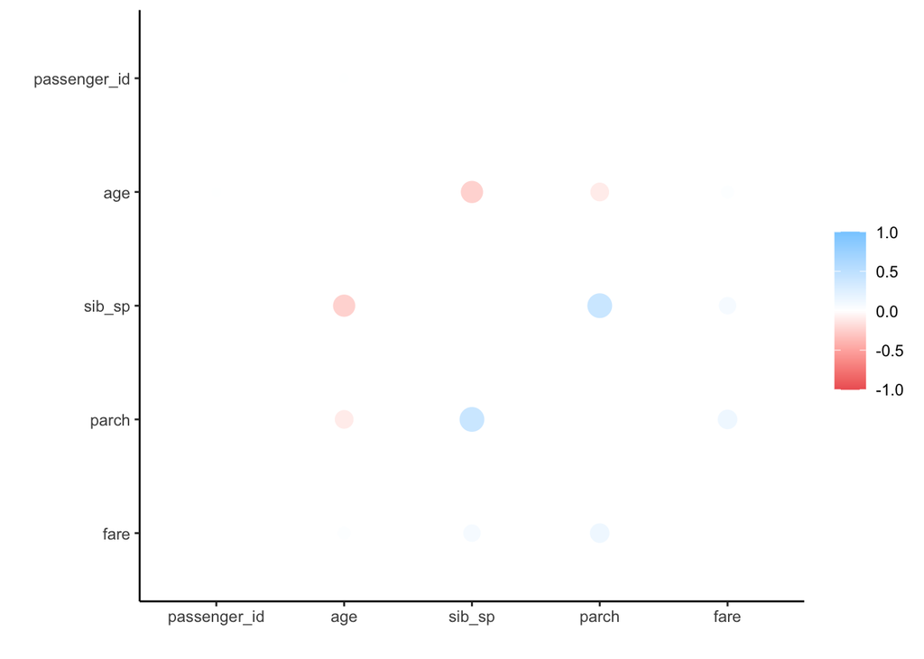

```r
# correlation matrix
titanic_df = as.data.frame(titanic_train[,sapply(titanic_train,is.numeric)])
cor_titanic_train <- titanic_df %>%
  correlate()
rplot(cor_titanic_train)
```

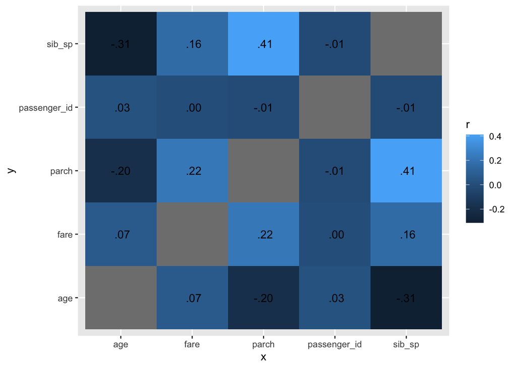

```r
# create a heatmap-style correlation plot
cor_titanic_train %>%
  stretch() %>%
  ggplot(aes(x, y, fill = r)) +
  geom_tile() +
  geom_text(aes(label = as.character(fashion(r))))
```

Are any predictors correlated with each other? Which ones, and in which direction?

There is not a lot of correlation among the data. However, sib_sp and parch appear to have a slightly positive correlation. This would make sense as the number of siblings on board is highly effected by the number of parents.

### Question 4

Using the **training** data, create a recipe predicting the outcome variable `survived`. Include the following predictors: ticket class, sex, age, number of siblings or spouses aboard, number of parents or children aboard, and passenger fare.

Recall that there were missing values for `age`. To deal with this, add an imputation step using `step_impute_linear()`. Next, use `step_dummy()` to **dummy** encode categorical predictors. Finally, include interactions between:

- Sex and passenger fare, and
- Age and passenger fare.

You’ll need to investigate the `tidymodels` documentation to find the appropriate step functions to use.

```r
# create recipe
titanic_recipe <- recipe(survived ~ pclass + sex + age + sib_sp + parch + fare, data = titanic_train) %>%
  step_impute_linear(age) %>%
  step_dummy(all_nominal_predictors())
titanic_recipe
```

```
## Recipe
##
## Inputs:
##
##       role #variables
##    outcome          1
##  predictor          6
##
## Operations:
##
## Linear regression imputation for age
## Dummy variables from all_nominal_predictors()
```

```r
# interactions
interaction_1 <- step_interact(titanic_recipe, terms = ~ sex:fare)
interaction_1 <- prep(interaction_1, training = titanic_train)
interaction_2 <- step_interact(titanic_recipe, terms = ~ age:fare)
interaction_2 <- prep(interaction_2, training = titanic_train)
```

### Question 5

Specify a **logistic regression** model for classification using the `"glm"` engine. Then create a workflow. Add your model and the appropriate recipe. Finally, use `fit()` to apply your workflow to the **training** data.

*Hint: Make sure to store the results of `fit()`. You’ll need them later on.*

```r
# specify the model type to be logistic regression and engine to be glm
log_reg_titanic <- logistic_reg() %>%
  set_engine("glm") %>%
  set_mode("classification")

# set up the workflow and fit the model to the training data
log_wkflow <- workflow() %>%
  add_model(log_reg_titanic) %>%
  add_recipe(titanic_recipe)

log_fit <- fit(log_wkflow, titanic_train)
```

### Question 6

**Repeat Question 5**, but this time specify a linear discriminant analysis model for classification using the `"MASS"` engine.

```r
# specify the model type to be a linear discriminant analysis model and engine to be a 'MASS' engine
lda_mod <- discrim_linear() %>%
  set_mode("classification") %>%
  set_engine("MASS")

lda_wkflow <- workflow() %>%
  add_model(lda_mod) %>%
  add_recipe(titanic_recipe)

lda_fit <- fit(lda_wkflow, titanic_train)
```

### Question 7

**Repeat Question 5**, but this time specify a quadratic discriminant analysis model for classification using the `"MASS"` engine.

```r
# specify the model type to be a quadratic discriminant analysis model and engine to be a 'MASS' engine
qda_mod <- discrim_quad() %>%
  set_mode("classification") %>%
  set_engine("MASS")

qda_wkflow <- workflow() %>%
  add_model(qda_mod) %>%
  add_recipe(titanic_recipe)

qda_fit <- fit(qda_wkflow, titanic_train)
```

### Question 8

**Repeat Question 5**, but this time specify a naive Bayes model for classification using the `"klaR"` engine. Set the `usekernel` argument to `FALSE`.

```r
# specify the model type to be a naive Bayes model and engine to be a 'klaR' engine
nb_mod <- naive_Bayes() %>%
  set_mode("classification") %>%
  set_engine("klaR") %>%
  set_args(usekernel = FALSE)

nb_wkflow <- workflow() %>%
  add_model(nb_mod) %>%
  add_recipe(titanic_recipe)

nb_fit <- fit(nb_wkflow, titanic_train)
```

### Question 9

Now you’ve fit four different models to your training data.

Use `predict()` and `bind_cols()` to generate predictions using each of these 4 models and your **training** data. Then use the *accuracy* metric to assess the performance of each of the four models.

```r
# prediction logistics regression
log_predict <- predict(log_fit, new_data = titanic_train, type = "prob")

# prediction linear discriminant
lda_predict <- predict(lda_fit, new_data = titanic_train, type = "prob")

# prediction quadratic discriminant
dqa_predict <- predict(qda_fit, new_data = titanic_train, type = "prob")

# prediction naive Bayes
nb_predict <- predict(nb_fit, new_data = titanic_train, type = "prob")

all_prediction <- bind_cols(log_predict, lda_predict, dqa_predict, nb_predict)
colnames(all_prediction) <- c("Log Pred No", "Log Pred Yes", "Lda Pred No", "Lda Pred Yes", "dqa Pred No", "dqa Pred Yes", "nb Pred No", "nb Pred Yes")
head(all_prediction)
```

```
## # A tibble: 6 × 8
##   `Log Pred No` `Log Pred Yes` `Lda Pred No` `Lda Pred Yes` `dqa Pred No`
##           <dbl>          <dbl>         <dbl>          <dbl>         <dbl>
## 1         0.915         0.0850         0.947        0.0526          0.974
## 2         0.926         0.0740         0.957        0.0429          0.963
## 3         0.903         0.0973         0.943        0.0572          0.956
## 4         0.753         0.247          0.825        0.175           0.869
## 5         0.846         0.154          0.907        0.0934          0.931
## 6         0.984         0.0159         0.992        0.00766         0.976
## # … with 3 more variables: `dqa Pred Yes` <dbl>, `nb Pred No` <dbl>,
## #   `nb Pred Yes` <dbl>
```

```r
# calculate accuracy of logistics regression
log_acc <- augment(log_fit, new_data = titanic_train) %>%
  accuracy(truth = survived, estimate = .pred_class)

# calculate accuracy of linear discriminant
lda_acc <- augment(lda_fit, new_data = titanic_train) %>%
  accuracy(truth = survived, estimate = .pred_class)

# calculate accuracy of quadratic discriminant
qda_acc <- augment(qda_fit, new_data = titanic_train) %>%
  accuracy(truth = survived, estimate = .pred_class)

# calculate accuracy of naive Bayes
nb_acc <- augment(nb_fit, new_data = titanic_train) %>%
  accuracy(truth = survived, estimate = .pred_class)

accuracies <- c(log_acc$.estimate, lda_acc$.estimate,
                nb_acc$.estimate, qda_acc$.estimate)
models <- c("Logistic Regression", "LDA", "Naive Bayes", "QDA")
results <- tibble(models = models, accuracies = accuracies)
results %>%
  arrange(-accuracies)
```

```
## # A tibble: 4 × 2
##   models              accuracies
##   <chr>                    <dbl>
## 1 Logistic Regression      0.822
## 2 QDA                      0.820
## 3 LDA                      0.808
## 4 Naive Bayes              0.806
```

Which model achieved the highest accuracy on the training data?

The logistic regression model achieved the highest accuracy on the training data!

### Question 10

Fit the model with the highest training accuracy to the **testing** data. Report the accuracy of the model on the **testing** data.

```r
# fit to testing data
log_fit_test <- fit(log_wkflow, titanic_test)

# prediction logistics regression
log_predict_test <- predict(log_fit_test, new_data = titanic_test, type = "prob")

# calculate accuracy
log_acc_test <- augment(log_fit_test, new_data = titanic_test) %>%
  accuracy(truth = survived, estimate = .pred_class)
log_acc_test
```

```
## # A tibble: 1 × 3
##   .metric  .estimator .estimate
##   <chr>    <chr>          <dbl>
## 1 accuracy binary         0.771
```

The accuracy of the model is reported as 0.7709497.

Again using the **testing** data, create a confusion matrix and visualize it. Plot an ROC curve and calculate the area under it (AUC).

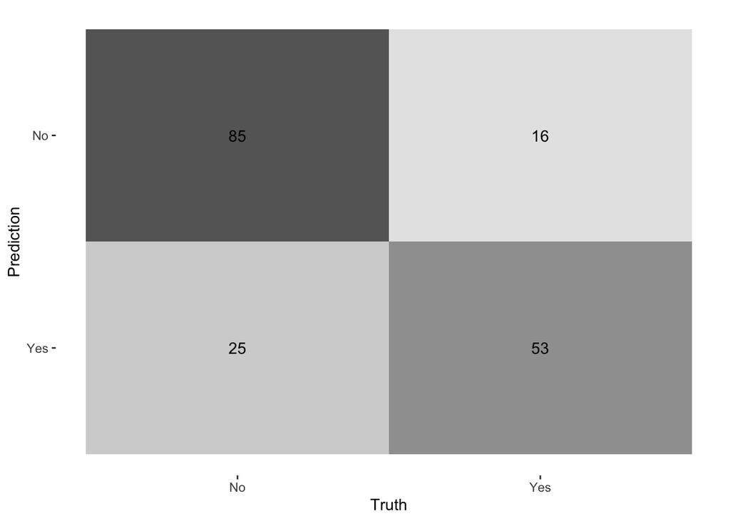

```r
# confusion matrix
augment(log_fit_test, new_data = titanic_test) %>%
  conf_mat(truth = survived, estimate = .pred_class) %>%
  autoplot(type = "heatmap")
```

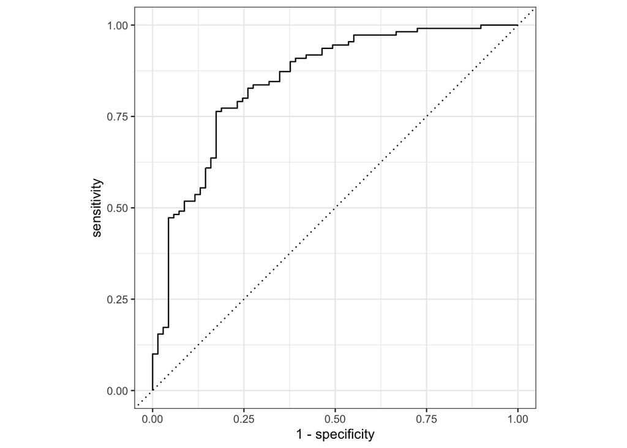

```r
augment(log_fit_test, new_data = titanic_test) %>%
  roc_curve(survived, .pred_No) %>%
  autoplot()
```

```r
auc(titanic_test$survived, log_predict_test$.pred_No)
```

```
## Area under the curve: 0.8468
```

How did the model perform? Compare its training and testing accuracies. If the values differ, why do you think this is so?

The accuracy of the model on the testing data is reported as 0.7709497, which is less than the accuracy of 0.8216292 that was achieved by the model when acting on the training data.